# TP1 Analyse en Composantes Principales

Ghazi Bel Mufti

26 mars 2020

# Objectifs de l’ACP

L’ACP permet de décrire un jeu de données, de le résumer, d’en réduire la dimensionnalité. L’ACP réalisée sur les individus du tableau de données répond à différentes questions :

- Etude des individus (i.e. des athlètes) : deux athlètes sont proches s’ils ont des résultats similaires. On s’intéresse à la variabilité entre individus. Y a-t-il des similarités entre les individus pour toutes les variables ? Peut-on établir des profils d’athlètes ? Peut-on opposer un groupe d’individus à un autre ?
- Etude des variables (i.e. des performances) : on étudie les liaisons linéaires entre les variables. Les objectifs sont de résumer la matrice des corrélations et de chercher des variables synthétiques: peut-on résumer les performances des athlètes par un petit nombre de variables ?
- Lien entre les deux études : peut-on caractériser des groups d’individus par des variables ?

# Importer et explorer le jeu de données

```r
library(FactoMineR)
data(decathlon)
head(decathlon)
```

```
##          100m Long.jump Shot.put High.jump  400m 110m.hurdle Discus
## SEBRLE  11.04      7.58    14.83      2.07 49.81       14.69  43.75
## CLAY    10.76      7.40    14.26      1.86 49.37       14.05  50.72
## KARPOV  11.02      7.30    14.77      2.04 48.37       14.09  48.95
## BERNARD 11.02      7.23    14.25      1.92 48.93       14.99  40.87
## YURKOV  11.34      7.09    15.19      2.10 50.42       15.31  46.26
## WARNERS 11.11      7.60    14.31      1.98 48.68       14.23  41.10
##         Pole.vault Javeline 1500m Rank Points Competition
## SEBRLE        5.02    63.19 291.7    1   8217    Decastar
## CLAY          4.92    60.15 301.5    2   8122    Decastar
## KARPOV        4.92    50.31 300.2    3   8099    Decastar
## BERNARD       5.32    62.77 280.1    4   8067    Decastar
## YURKOV        4.72    63.44 276.4    5   8036    Decastar
## WARNERS       4.92    51.77 278.1    6   8030    Decastar
```

```r
tail(decathlon)
```

```
##              100m Long.jump Shot.put High.jump  400m 110m.hurdle Discus
## Turi        11.08      6.91    13.62      2.03 51.67       14.26  39.83
## Lorenzo     11.10      7.03    13.22      1.85 49.34       15.38  40.22
## Karlivans   11.33      7.26    13.30      1.97 50.54       14.98  43.34
## Korkizoglou 10.86      7.07    14.81      1.94 51.16       14.96  46.07
## Uldal       11.23      6.99    13.53      1.85 50.95       15.09  43.01
## Casarsa     11.36      6.68    14.92      1.94 53.20       15.39  48.66
##             Pole.vault Javeline  1500m Rank Points Competition
## Turi               4.8    59.34 290.01   23   7708    OlympicG
## Lorenzo            4.5    58.36 263.08   24   7592    OlympicG
## Karlivans          4.5    52.92 278.67   25   7583    OlympicG
## Korkizoglou        4.7    53.05 317.00   26   7573    OlympicG
## Uldal              4.5    60.00 281.70   27   7495    OlympicG
## Casarsa            4.4    58.62 296.12   28   7404    OlympicG
```

```r
str(decathlon) # competition variable nominale, catégorielle comme sexe (H ou F). Le reste des variables sont des variables quantitatives.
```

```
## 'data.frame':    41 obs. of  13 variables:
##  $ 100m       : num  11 10.8 11 11 11.3 ...
##  $ Long.jump  : num  7.58 7.4 7.3 7.23 7.09 7.6 7.3 7.31 6.81 7.56 ...
##  $ Shot.put   : num  14.8 14.3 14.8 14.2 15.2 ...
##  $ High.jump  : num  2.07 1.86 2.04 1.92 2.1 1.98 2.01 2.13 1.95 1.86 ...
##  $ 400m       : num  49.8 49.4 48.4 48.9 50.4 ...
##  $ 110m.hurdle: num  14.7 14.1 14.1 15 15.3 ...
##  $ Discus     : num  43.8 50.7 49 40.9 46.3 ...
##  $ Pole.vault : num  5.02 4.92 4.92 5.32 4.72 4.92 4.42 4.42 4.92 4.82 ...
##  $ Javeline   : num  63.2 60.1 50.3 62.8 63.4 ...
##  $ 1500m      : num  292 302 300 280 276 ...
##  $ Rank       : int  1 2 3 4 5 6 7 8 9 10 ...
##  $ Points     : int  8217 8122 8099 8067 8036 8030 8004 7995 7802 7733 ...
##  $ Competition: Factor w/ 2 levels "Decastar","OlympicG": 1 1 1 1 1 1 1 1 1 1 ...
```

```r
summary(decathlon)
```

```
##       100m         Long.jump       Shot.put       High.jump
##  Min.   :10.44   Min.   :6.61   Min.   :12.68   Min.   :1.850
##  1st Qu.:10.85   1st Qu.:7.03   1st Qu.:13.88   1st Qu.:1.920
##  Median :10.98   Median :7.30   Median :14.57   Median :1.950
##  Mean   :11.00   Mean   :7.26   Mean   :14.48   Mean   :1.977
##  3rd Qu.:11.14   3rd Qu.:7.48   3rd Qu.:14.97   3rd Qu.:2.040
##  Max.   :11.64   Max.   :7.96   Max.   :16.36   Max.   :2.150
##       400m        110m.hurdle        Discus        Pole.vault
##  Min.   :46.81   Min.   :13.97   Min.   :37.92   Min.   :4.200
##  1st Qu.:48.93   1st Qu.:14.21   1st Qu.:41.90   1st Qu.:4.500
##  Median :49.40   Median :14.48   Median :44.41   Median :4.800
##  Mean   :49.62   Mean   :14.61   Mean   :44.33   Mean   :4.762
##  3rd Qu.:50.30   3rd Qu.:14.98   3rd Qu.:46.07   3rd Qu.:4.920
##  Max.   :53.20   Max.   :15.67   Max.   :51.65   Max.   :5.400
##     Javeline         1500m            Rank           Points
##  Min.   :50.31   Min.   :262.1   Min.   : 1.00   Min.   :7313
##  1st Qu.:55.27   1st Qu.:271.0   1st Qu.: 6.00   1st Qu.:7802
##  Median :58.36   Median :278.1   Median :11.00   Median :8021
##  Mean   :58.32   Mean   :279.0   Mean   :12.12   Mean   :8005
##  3rd Qu.:60.89   3rd Qu.:285.1   3rd Qu.:18.00   3rd Qu.:8122
##  Max.   :70.52   Max.   :317.0   Max.   :28.00   Max.   :8893
##    Competition
##  Decastar:13
##  OlympicG:28
##
##
##
##
```

# ACP normée pas à pas

On commence par définir la matrice $X$ composée des scores des dix épreuves du decathlon. On définit la matrice des poids $D=\displaystyle\frac{1}{n}I_n$, $n$ étant la taille de l’échantillon ainsi que la métrique $M=I_p$.

## 1. Calcul de la matrice centrée réduite

Centrer et réduire la matrice $X$

```r
X=as.matrix(decathlon[,1:10])
g=colMeans(X)
g
```

```
##        100m   Long.jump    Shot.put   High.jump        400m 110m.hurdle
##   10.998049    7.260000   14.477073    1.976829   49.616341   14.605854
##      Discus  Pole.vault    Javeline       1500m
##   44.325610    4.762439   58.316585  279.024878
```

```r
Y=sweep(x = X,2,g,FUN = '-')
round(colMeans(X),3)
```

```
##        100m   Long.jump    Shot.put   High.jump        400m 110m.hurdle
##      10.998       7.260      14.477       1.977      49.616      14.606
##      Discus  Pole.vault    Javeline       1500m
##      44.326       4.762      58.317     279.025
```

Calcul des écarts-types pour réduire les variables.

```r
n=nrow(X)
p=ncol(X)
et=apply(Y,2,function(x) sqrt(sum(x^2)/n))
et
```

```
##        100m   Long.jump    Shot.put   High.jump        400m 110m.hurdle
##  0.25979560  0.31251927  0.81431175  0.08785906  1.13929751  0.46599998
##      Discus  Pole.vault    Javeline       1500m
##  3.33639725  0.27458865  4.76759315 11.53001177
```

Calcul de la matrice des données entrées réduites $Z$. On vérifie que les variables de cette matrice sont bien de variance égale à 1.

```r
Z=sweep(x = Y,2,et,FUN = '/')
colSums(Z^2)/n
```

```
##        100m   Long.jump    Shot.put   High.jump        400m 110m.hurdle
##           1           1           1           1           1           1
##      Discus  Pole.vault    Javeline       1500m
##           1           1           1           1
```

## 2. Calcul de la matrice des corrélations

Calcul de la matrice des corrélations $R=Z'DZ$, ses valeurs propres et ses vecteurs propres.

```r
M=diag(rep(1,p))
D=(1/n)*diag(rep(1,n))
R=t(Z)%*%D%*%Z
vp=eigen(R %*%M)
lambda=vp$values
lambda
```

```
##  [1] 3.2719055 1.7371310 1.4049167 1.0568504 0.6847735 0.5992687 0.4512353
##  [8] 0.3968766 0.2148149 0.1822275
```

```r
U=vp$vectors
U
```

```
##              [,1]       [,2]        [,3]        [,4]        [,5]
##  [1,]  0.42829627  0.1419891  0.15557953  0.03678703 -0.36518741
##  [2,] -0.41015201 -0.2620794 -0.15372674 -0.09901016 -0.04432336
##  [3,] -0.34414444  0.4539470  0.01972378 -0.18539458 -0.13431954
##  [4,] -0.31619436  0.2657761  0.21894349  0.13189684 -0.67121760
##  [5,]  0.37571570  0.4320460 -0.11091758 -0.02850297  0.10597034
##  [6,]  0.41255442  0.1735910  0.07815576 -0.28290068 -0.19857266
##  [7,] -0.30542571  0.4600244 -0.03623770  0.25259074  0.12667770
##  [8,] -0.02783081 -0.1368411 -0.58361717 -0.53649480 -0.39873734
##  [9,] -0.15319802  0.2405071  0.32874217 -0.69285498  0.36873120
## [10,]  0.03210733  0.3598049 -0.65987362  0.15669648  0.18557094
##              [,6]        [,7]        [,8]        [,9]       [,10]
##  [1,]  0.29607739 -0.38177608  0.46160211  0.10475771  0.42428269
##  [2,] -0.30612478 -0.62769317 -0.02101165  0.48266910  0.08104448
##  [3,]  0.30547299  0.30972542 -0.31393005  0.42729075  0.39028424
##  [4,] -0.46777116  0.09145002  0.12509166 -0.24366054 -0.10642724
##  [5,] -0.33252178  0.12442114  0.21339819  0.55212939 -0.41399532
##  [6,] -0.09963776 -0.35733030 -0.71111429 -0.15013429 -0.09086448
##  [7,]  0.44937288 -0.42988982  0.03838986 -0.15480715 -0.44916580
##  [8,]  0.26166458  0.09796019  0.17803824 -0.08297769 -0.27645138
##  [9,] -0.16320268 -0.10674519  0.29614206 -0.24732691  0.08777340
## [10,] -0.29826888 -0.08362898  0.01371744 -0.30773397  0.42923132
```

Vérifions que les vecteurs propres (i.e. les colonnes de $U$) sont bien orthornormés.

```r
round(t(U)%*%U,3)
```

```
##       [,1] [,2] [,3] [,4] [,5] [,6] [,7] [,8] [,9] [,10]
##  [1,]    1    0    0    0    0    0    0    0    0     0
##  [2,]    0    1    0    0    0    0    0    0    0     0
##  [3,]    0    0    1    0    0    0    0    0    0     0
##  [4,]    0    0    0    1    0    0    0    0    0     0
##  [5,]    0    0    0    0    1    0    0    0    0     0
##  [6,]    0    0    0    0    0    1    0    0    0     0
##  [7,]    0    0    0    0    0    0    1    0    0     0
##  [8,]    0    0    0    0    0    0    0    1    0     0
##  [9,]    0    0    0    0    0    0    0    0    1     0
## [10,]    0    0    0    0    0    0    0    0    0     1
```

## 3. Les composantes principales

Calculons la matrice $Psi$ des composantes principales qui est donnée par $Psi=Zu$. On verifiera que la variance de chaque composante est égale à la valeur propore correspondante.

```r
Psi=Z%*%U
Psi
```

```
##                     [,1]        [,2]          [,3]        [,4]        [,5]
## SEBRLE      -0.791627717  0.77161120 -0.8268411940 -1.17462736 -0.70715903
## CLAY        -1.234990563  0.57457807 -2.1412469664  0.35484483  1.97457138
## KARPOV      -1.358214936  0.48402090 -1.9562579869  1.85652411 -0.79521472
## BERNARD      0.609515083 -0.87462853 -0.8899406619 -2.22061245 -0.36163619
## YURKOV       0.585968338  2.13095422  1.2251567968 -0.87357915 -1.25136918
## WARNERS     -0.356889530 -1.68495667 -0.7665531449  0.58930466 -1.00166155
## ZSIVOCZKY   -0.271774781 -1.09377558  1.2827673831  1.62156457 -0.04407327
## McMULLEN    -0.587516189  0.23072991  0.4176329823  1.52423275 -0.25151965
## MARTINEAU    1.995359298  0.56099598  0.7299466011  0.54219127 -1.57821348
## HERNU        1.546076462  0.48838301 -0.8407858519 -0.33119470  0.23498029
## BARRAS       1.341652727 -0.31091157  0.0003683375  0.64525336 -0.31628748
## NOOL         2.344973806 -1.96637500  1.3364815492 -0.19530310 -0.83022767
## BOURGUIGNON  3.979041865  0.19986019 -1.3264851034 -0.52435051 -0.29001247
## Sebrle      -4.038448501  1.36582606  0.2899565043 -1.94113411 -0.37695454
## Clay        -3.919365157  0.83696136 -0.2311753205 -1.49397212  1.03760852
## Karpov      -4.619987275  0.03999523  0.0415857980  1.31352566 -0.18772953
## Macey       -2.233460566  1.04176620  1.8643620154  0.74321353 -0.97727010
## Warners     -2.168396445 -1.80320025 -0.8510173287  0.28459958  0.15139464
## Zsivoczky   -0.925132183  1.16865180  1.4774802908 -0.80759472 -0.87297257
## Hernu       -0.889037852 -0.61842522  0.8982953480  0.13478508 -0.63498488
## Nool        -0.295305667 -1.54561667 -1.3552601286 -2.19972249  0.03538887
## Bernard     -1.906334368 -0.08580429  0.7571859709  1.45097918 -0.34164564
## Schwarzl    -0.081078659 -1.35345710 -0.8224866222 -0.39909143 -0.28836991
## Pogorelov   -0.539677028  0.77075099 -1.3476197769  0.55215692 -0.97229498
## Schoenbeck  -0.114430985 -0.03985061 -0.7404039810 -0.92884762  0.85442565
## Barras      -0.002145203  0.36033768  1.5696934888 -0.61238304  0.67506540
## Smith       -0.870310570  1.05932552  1.6434290616  1.12132654  2.01990789
## Averyanov   -0.349155138 -1.55864999 -0.2825354037  0.02726334  0.36098809
## Ojaniemi    -0.380113999 -0.77244734  0.3709431419 -0.68727919  0.49925676
## Smirnov      0.484514213 -1.06066118  1.2283378499 -0.56603194  0.40718384
## Qi           0.434466691 -0.32614690  1.0697978123  0.20497404  0.53559673
## Drews        0.248684024 -3.08167683 -1.0548427375  0.64577513  0.17841420
## Parkhomenko  1.069429104  2.09318218  0.9999839029 -1.53455272 -0.28180687
## Terek        0.681953059  0.53561440 -2.2091259997 -0.10862305 -1.04315650
## Gomez        0.289889208 -1.19671611  1.3061025895 -0.07785116  1.26143770
## Turi         1.541813056  0.42716773 -0.5140859441  0.14284738  0.03871969
## Lorenzo      2.408509980 -1.58292969  1.5023461069 -0.30103076  0.68195932
## Karlivans    1.994368727 -0.29418240  0.3427836937  1.27206999 -0.37322060
## Korkizoglou  0.957829813  2.06638554 -2.5865525263  1.19146757  0.80089104
```

[output cut: 29 more lines]

```
## Smith        1.29179510  0.92942803  0.10317674 -0.191201887  0.089439874
## Averyanov   -0.61650428  1.35164082 -0.76357457  0.751397746 -0.487116486
## Ojaniemi    -0.79491103  0.22760918 -1.62981377  0.505551532  0.517965031
## Smirnov      0.15711173  0.36720227 -0.26809288 -0.455029343 -0.540450528
## Qi          -0.42721799 -0.94756780  0.17805603 -0.274429259 -0.396922190
## Drews        0.18998231  0.46206001  0.54928962 -0.075890729 -0.192719322
## Parkhomenko -0.02343641  1.72466895  0.21356688 -0.115141938  0.395896413
## Terek        1.23637214  0.68973066 -1.32531512 -0.389166469 -0.358281849
## Gomez        0.49836092  0.14287075 -0.09667920  0.399815735  1.252146708
## Turi        -1.58272797  1.29143851  1.53696070 -0.147061945 -0.115731380
## Lorenzo      0.06822736 -0.37175217 -0.96612514 -0.312209844 -0.168379968
## Karlivans   -0.56539057 -0.97187597  0.11879004  0.276702842 -0.138001002
## Korkizoglou -0.80314710  0.16523591 -0.96695318 -0.240688329  0.444241723
## Uldal       -0.19808228 -0.49760283  0.04826482  0.003274377  0.001399909
## Casarsa     -0.08494663 -0.26532308 -0.21238691  0.505220025 -0.334146282
```

```r
round(t(Psi)%*%D%*%Psi,3)
```

```
##        [,1]  [,2]  [,3]  [,4]  [,5]  [,6]  [,7]  [,8]  [,9] [,10]
##  [1,] 3.272 0.000 0.000 0.000 0.000 0.000 0.000 0.000 0.000 0.000
##  [2,] 0.000 1.737 0.000 0.000 0.000 0.000 0.000 0.000 0.000 0.000
##  [3,] 0.000 0.000 1.405 0.000 0.000 0.000 0.000 0.000 0.000 0.000
##  [4,] 0.000 0.000 0.000 1.057 0.000 0.000 0.000 0.000 0.000 0.000
##  [5,] 0.000 0.000 0.000 0.000 0.685 0.000 0.000 0.000 0.000 0.000
##  [6,] 0.000 0.000 0.000 0.000 0.000 0.599 0.000 0.000 0.000 0.000
##  [7,] 0.000 0.000 0.000 0.000 0.000 0.000 0.451 0.000 0.000 0.000
##  [8,] 0.000 0.000 0.000 0.000 0.000 0.000 0.000 0.397 0.000 0.000
##  [9,] 0.000 0.000 0.000 0.000 0.000 0.000 0.000 0.000 0.215 0.000
## [10,] 0.000 0.000 0.000 0.000 0.000 0.000 0.000 0.000 0.000 0.182
```

## 4. Les coordonnées des variables sur les axes

Calculons la matrice $Eta$ des coordonnées des variables sur les axes principaux par $Eta_\alpha = \sqrt{(\lambda_\alpha)} u_\alpha$.

```r
Eta<-sweep(U,2,sqrt(lambda),FUN='*')
Eta
```

```
##              [,1]       [,2]        [,3]        [,4]        [,5]
##  [1,]  0.77471983  0.1871420  0.18440714  0.03781826 -0.30219639
##  [2,] -0.74189974 -0.3454213 -0.18221105 -0.10178564 -0.03667805
##  [3,] -0.62250255  0.5983033  0.02337844 -0.19059161 -0.11115082
##  [4,] -0.57194530  0.3502936  0.25951193  0.13559420 -0.55543957
##  [5,]  0.67960994  0.5694378 -0.13146970 -0.02930198  0.08769157
##  [6,]  0.74624532  0.2287933  0.09263738 -0.29083103 -0.16432095
##  [7,] -0.55246652  0.6063134 -0.04295225  0.25967143  0.10482712
##  [8,] -0.05034151 -0.1803569 -0.69175665 -0.55153397 -0.32995932
##  [9,] -0.27711085  0.3169891  0.38965541 -0.71227728  0.30512892
## [10,]  0.05807706  0.4742238 -0.78214280  0.16108904  0.15356189
##              [,6]        [,7]         [,8]        [,9]       [,10]
##  [1,]  0.22920075 -0.25645445  0.290800753  0.04855323  0.18111827
##  [2,] -0.23697868 -0.42164691 -0.013236949  0.22370807  0.03459636
##  [3,]  0.23647411  0.20805510 -0.197770097  0.19804125  0.16660497
##  [4,] -0.36211310  0.06143068  0.078805424 -0.11293209 -0.04543178
##  [5,] -0.25741324  0.08357871  0.134436894  0.25590161 -0.17672678
##  [6,] -0.07713202 -0.24003322 -0.447988786 -0.06958442 -0.03878833
##  [7,]  0.34787054 -0.28877439  0.024184898 -0.07175021 -0.19174040
##  [8,]  0.20256095  0.06580383  0.112160780 -0.03845860 -0.11801187
##  [9,] -0.12633919 -0.07170506  0.186563995 -0.11463138  0.03746881
## [10,] -0.23089724 -0.05617697  0.008641731 -0.14262892  0.18323074
```

# ACP normée avec le package FactoMineR et interprétation de l’ACP.

Utilisons maintenant la fonction PCA pour retrouver les résultats obtenus précédemment.

- On va ajouter deux types de variables comme variables supplémentaires : on ajoute les variables “Rank” and “Points” comme variables continues illustratives et la variable “compétition” comme variable qualitative illustrative. Les variables illustratives n’influencent pas la construction des composantes principales de l’analyse.
- Notons que nous utilisons le package factoextra plutôt que FactoMineR pour la qualité de ces graphiques.

## 1. Pertinence de l’ACP

Le corrgram donné ci-dessous permet d’étudier les corrélations entre les variables quantitatives : il est clair qu’il existe des corrélations importantes entre des groupes de variables ce qui suggère la pertinence de cette ACP (par exemple, 100m, 400m et 110m.hurdle).

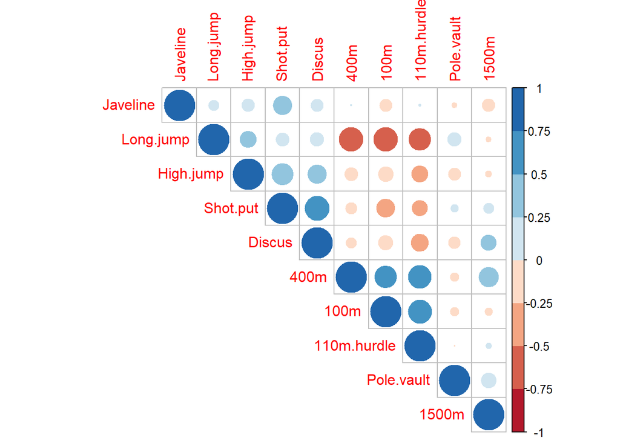

```r
library(corrplot)
X=as.matrix(decathlon[,c(1:10)])
M<-cor(X)
library(RColorBrewer)
corrplot(M, type="upper", order="hclust",
         col=brewer.pal(n=8, name="RdBu"))
```

Execution de la fonction PCA.

```r
library(factoextra)
```

```r
res.pca=PCA(decathlon,ncp = 5,quanti.sup = 11:12,quali.sup = 13,graph = F)
```

## 2. Choix du nombre d’axes à retenir

Trois critères devront être utlisés : taux d’inertie cumulé, critère de Kaiser et critère du coude.

L’objet $\tt eig$ est une matrice à trois colonnes contenants respectivement les valeurs propres de l’ACP, la proportion de variance de chaque composante et les variance cumulées par les composantes principales.

```r
head(res.pca$eig)
```

```
##        eigenvalue percentage of variance cumulative percentage of variance
## comp 1  3.2719055              32.719055                          32.71906
## comp 2  1.7371310              17.371310                          50.09037
## comp 3  1.4049167              14.049167                          64.13953
## comp 4  1.0568504              10.568504                          74.70804
## comp 5  0.6847735               6.847735                          81.55577
## comp 6  0.5992687               5.992687                          87.54846
```

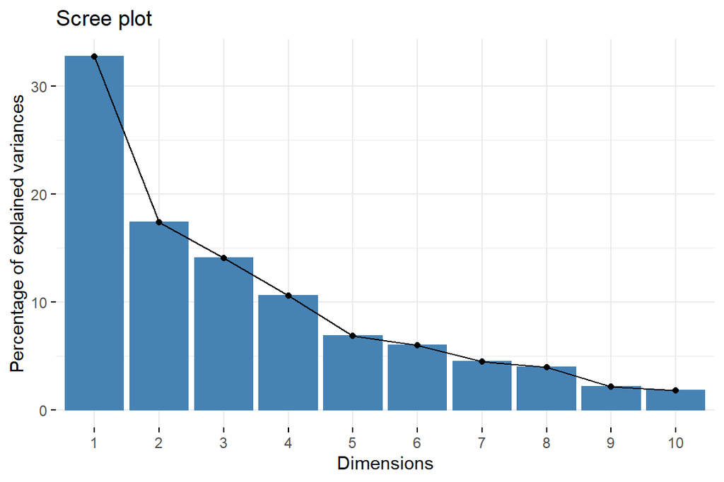

```r
fviz_screeplot(res.pca, ncp=10)
```

1. Critère de kaiser : on remarque qu’il y a 4 axes dont les valeurs propres sont supérieures à 1 donc on retient 4 axes d’après ce critère.
2. Critère du taux d’inertie cumulée : On remarque que le taux d’inertie cumulé des 2 premiers axes est de 50.09% qui est un taux important compte tenu du fait que nous avons 10 variables : on va donc, d’après ce critère, retenir les 2 premiers axes. (Remarquons que retenir 3 axes pour u taux d’inertie de 64.13% est envisageable aussi).
3. Critère du coude : On remarque que le coude se trouve au niveau du deuxième axe (voir la figure Scree plot), d’après ce critère, on devrait retenir les 2 premiers axes.

En faisant une sorte de vote des 3 critères on devrait retenir les 2 premiers axes.

## 3. Interprétation de la carte des variables

L’objet $\tt var$ de $\tt res.pca$ contient les 4 objets : $\tt coord$, $\tt cor$, $\tt cos2$ et $\tt contrib$. A noter que vu que notre ACP est normée, $\tt cor$ (i.e. la corrélations d’une variable avec la composante principale d’un axe) est identique à $\tt coord$ (i.e. la coordonnée de cette variable sur cet axe).

```r
names(res.pca$var)
```

```
## [1] "coord"   "cor"     "cos2"    "contrib"
```

L’objet $\tt coord$ dans $\tt var$ contient les coordonnées des variables.

```r
res.pca$var$coord
```

```
##                   Dim.1      Dim.2       Dim.3       Dim.4       Dim.5
## 100m        -0.77471983  0.1871420 -0.18440714 -0.03781826  0.30219639
## Long.jump    0.74189974 -0.3454213  0.18221105  0.10178564  0.03667805
## Shot.put     0.62250255  0.5983033 -0.02337844  0.19059161  0.11115082
## High.jump    0.57194530  0.3502936 -0.25951193 -0.13559420  0.55543957
## 400m        -0.67960994  0.5694378  0.13146970  0.02930198 -0.08769157
## 110m.hurdle -0.74624532  0.2287933 -0.09263738  0.29083103  0.16432095
## Discus       0.55246652  0.6063134  0.04295225 -0.25967143 -0.10482712
## Pole.vault   0.05034151 -0.1803569  0.69175665  0.55153397  0.32995932
## Javeline     0.27711085  0.3169891 -0.38965541  0.71227728 -0.30512892
## 1500m       -0.05807706  0.4742238  0.78214280 -0.16108904 -0.15356189
```

L’objet $\tt cos2$ dans $\tt var$ est une matrice dont les lignes représentent le cos carrés de la variable (soit le carrée des coordonnées puisque l’ACP est normée).

```r
res.pca$var$cos2
```

```
##                   Dim.1      Dim.2        Dim.3        Dim.4       Dim.5
## 100m        0.600190812 0.03502213 0.0340059930 0.0014302206 0.091322660
## Long.jump   0.550415232 0.11931587 0.0332008675 0.0103603165 0.001345279
## Shot.put    0.387509426 0.35796686 0.0005465513 0.0363251605 0.012354505
## High.jump   0.327121422 0.12270561 0.0673464410 0.0183857880 0.308513117
## 400m        0.461869674 0.32425938 0.0172842817 0.0008586058 0.007689811
## 110m.hurdle 0.556882084 0.05234639 0.0085816841 0.0845826853 0.027001375
## Discus      0.305219255 0.36761593 0.0018448960 0.0674292539 0.010988725
## Pole.vault  0.002534268 0.03252860 0.4785272696 0.3041897208 0.108873151
## Javeline    0.076790421 0.10048206 0.1518313365 0.5073389244 0.093103658
## 1500m       0.003372945 0.22488818 0.6117473613 0.0259496775 0.023581254
```

Interprétation de cette première carte des variables (i.e. axes 1 et 2) :

Les deux premières dimensions contiennent 50% de l’inertie totale (l’inertie est la variance totale du tableau de données, i.e. la trace de la matrice des corrélations).

La variable “X100m” est négativement corrélée à la variable “long.jump”. Quand un ahtlète réalise un temps faible au 100m, il peut sauter loin. Il faut faire attention ici qu’une petite valeur pour les variables “X100m”, “X400m”, “X110m.hurdle” et “X1500m” correspond à un score élevé : plus un athlète court rapidement, plus il gagne de points.

Le premier axe oppose les athlètes qui sont “bons partout” comme Karpov pendant les Jeux Olympiques à ceux qui sont “mauvais partout” comme Bourguignon pendant le Décastar. Cette dimension est particulièrement liée aux variables de vitesse et de saut en longueur qui constituent un groupe homogène. **Si on devait donner un nom à cet axe ça serait l’axe “Agilité”**.

Le deuxième axe oppose les athlètes qui sont forts (variables “Discus” et “Shot.put”) à ceux qui ne le sont pas. **Si on devait donner un nom à cet axe ça serait l’axe “Force”**.

Les variables “Discus”, “Shot.put” et “High.jump” ne sont pas très corrélées aux variables “X100m”, “X400m”, “X110m.hurdle” et “Long.jump”. Cela signifie que force et vitesse ne sont pas très corrélées.

*Variable quantitatives supplémentaires.* Les variables les plus liées, positivement (resp. négativement), au nombre de points (resp. Rang) sont les variables qui réfèrent à la vitesse (“X100m”, “X110m.hurdle”, “X400m”) et au saut en longueur. Au contraire, “Pole-vault” et “X1500m” n’ont pas une grande influence sur le nombre de points.

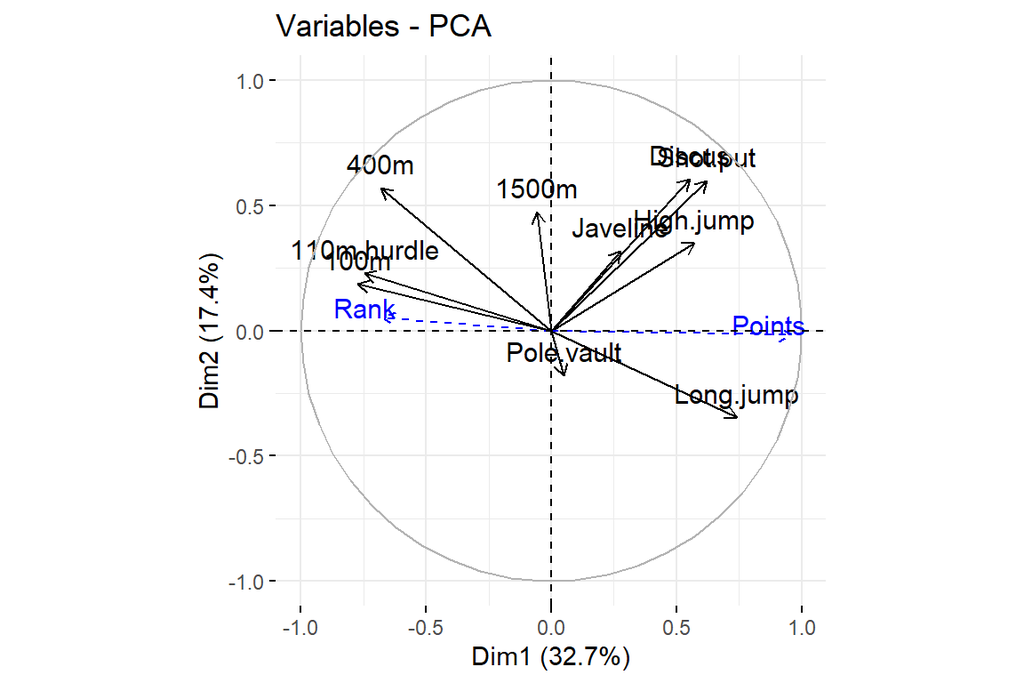

```r
fviz_pca_var(res.pca)
```

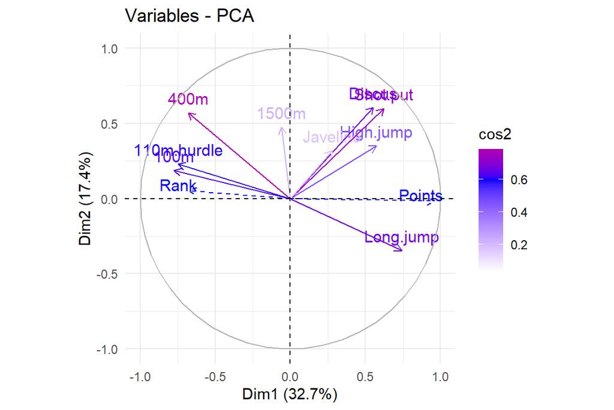

```r
fviz_pca_var(res.pca, col.var="cos2") +
  scale_color_gradient2(low="white", mid="blue",
                        high="red", midpoint=0.6) +
  theme_minimal()
```

Notons que la qualité de représentation d’une variable sur le premier plan est donnée par la somme de ses cos2 sur chacun des 2 premiers axes.

## 4. Interprétation de la carte des individus

De la même manière, l’objet $\tt ind$ de $\tt res.pca$ contient les objets : $\tt coord$, $\tt cos2$ et $\tt contrib$.

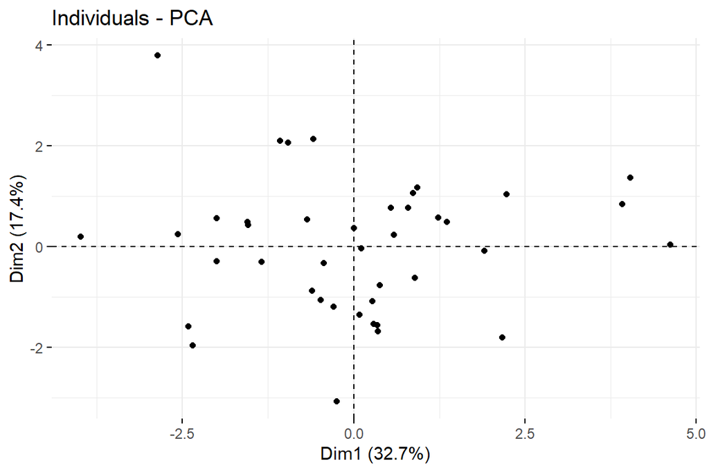

```r
fviz_pca_ind(res.pca,geom = "point",col.ind.sup = 'gray')
```

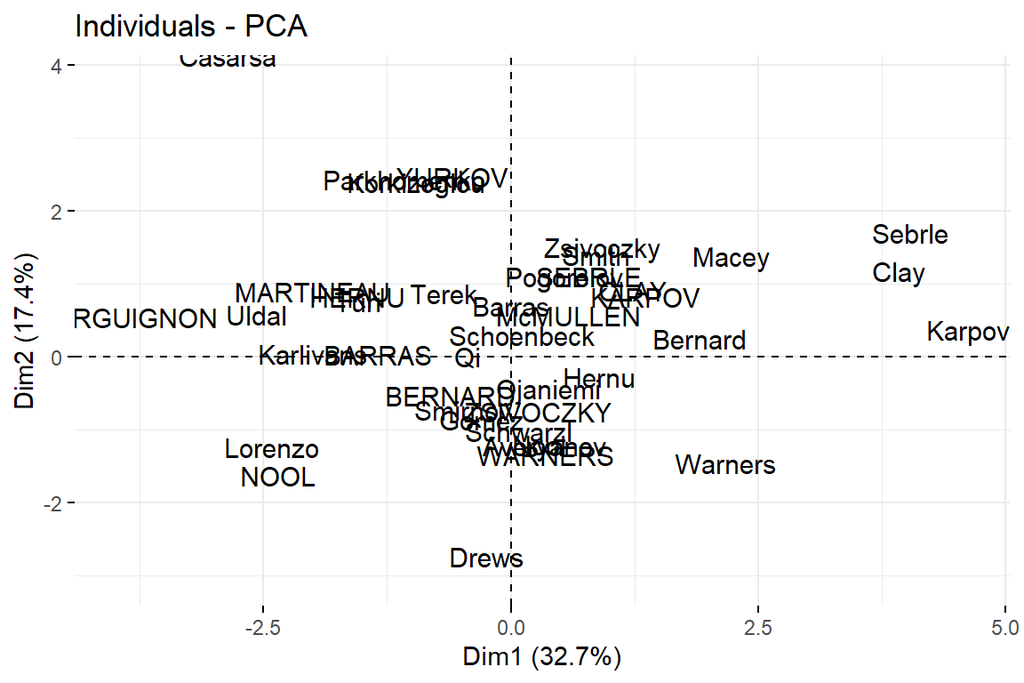

```r
fviz_pca_ind(res.pca,geom = "text",col.ind.sup = 'gray')
```

On distingue dans ce premier plan factoriel les groupe suivants : - Les athlètes rapides (comme Karpov) les athlètes rapides et puissants (comme Sebrle), les athlètes lents (comme Bourguignon ), les athlètes lents et puissants (comme Casarsa ), les athlètes rapides mais faibles (comme Warners) et les ahtlètes ni forts ni rapides (comme Lorenzo).

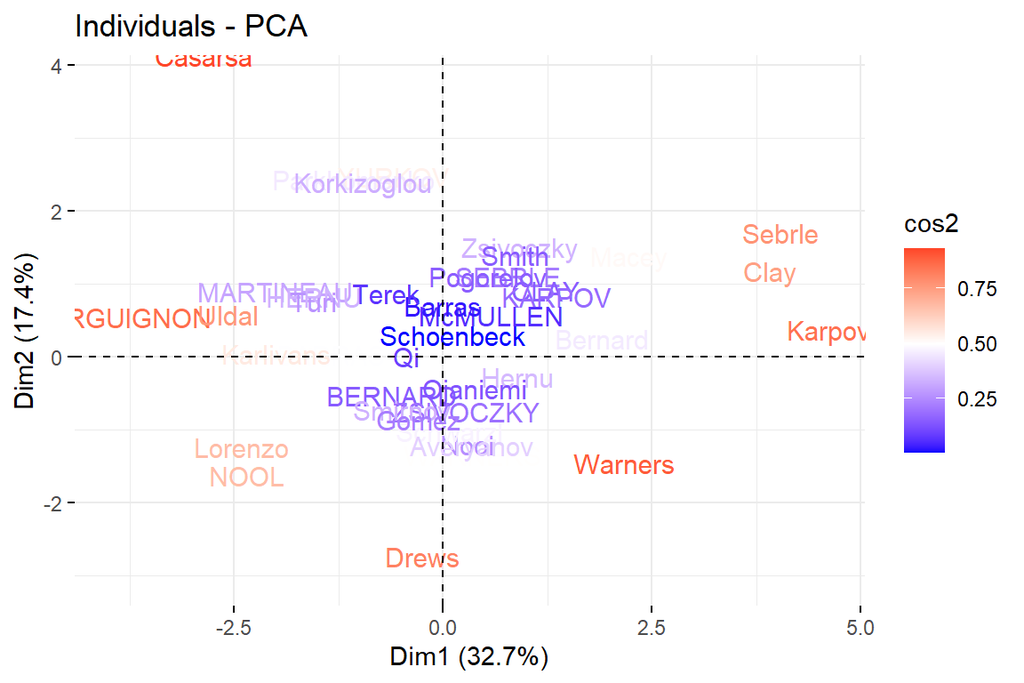

```r
fviz_pca_ind(res.pca,geom = "text",col.ind="cos2")+
scale_color_gradient2(low="blue", mid="white",
                      high="red", midpoint=0.5)
```

Notons que la qualité de représentation d’un individu sur le premier plan est donnée par la somme de ses cos2 sur chacun des 2 premiers axes.

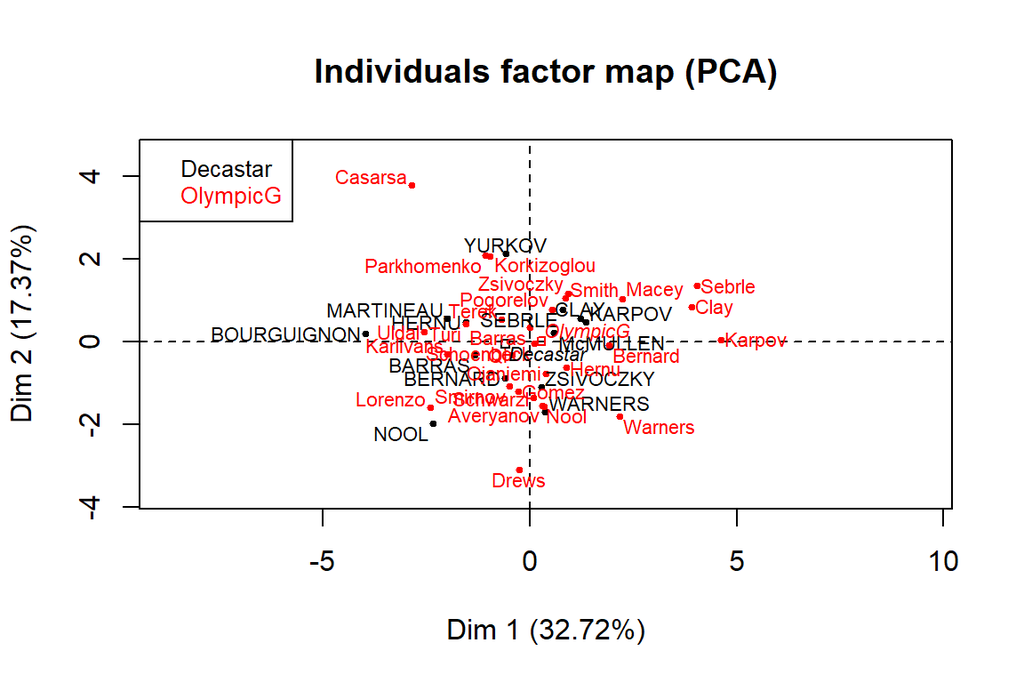

```r
plot.PCA(res.pca, axes=c(1, 2), choix="ind", habillage=13, cex=0.7)
```

En regardant les points qui représentent “Decastar” et “Olympic Games”, on voit que “Olympic Games” a une coordonnée plus élevée sur le premier axe que “Decastar”. Ceci montre une évolution des performances des athlètes. Tous les athlètes qui ont participé aux deux compétitions ont obtenu des résultats légèrement meilleurs aux jeux Olympiques.

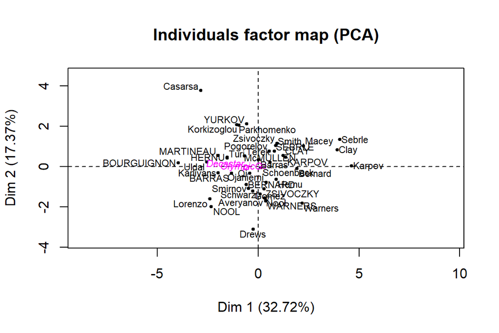

```r
res.pca = PCA(decathlon, quanti.sup=c(11: 12), quali.sup=13, graph=F)
plot(res.pca, choix="ind", cex=0.7)
```

*Variable qualitative supplémentaire.* On peut tirer les mêmes conclusions en nous basant sur les positions des modalités de la variable qualitative supplémentaire Compétition : “Olympic légèrement à droite de l’axe 1 par rapport à la modalité”Decastar".